# Tugas MPDW 3

Farrel Gilbran

2023-09-16

##Panggil Package

```r
library(dLagM)
library(dynlm)
library(MLmetrics)
library(lmtest)
library(car)
```

##Import Data

```r
library(readxl)
datap2 <- read_excel("C:/Users/farre/Downloads/data prak 2.xlsx")
X=datap2$o3
Y=datap2$AQI
View(datap2)
str(datap2)
```

```
## tibble [72 × 4] (S3: tbl_df/tbl/data.frame)
##  $ Periode: num [1:72] 1 2 3 4 5 6 7 8 9 10 ...
##  $ AQI    : num [1:72] 42.6 35.4 28.2 21 20 ...
##  $ o3     : num [1:72] 45.8 45.3 44.6 44.3 44 ...
##  $ date   : POSIXct[1:72], format: "2022-10-26" "2022-10-26" ...
```

## Pembagian Data

```r
#SPLIT DATA
train<-datap2[1:54,]
test<-datap2[55:72,]
```

```r
#data time series
train.ts<-ts(train)
test.ts<-ts(test)
data.ts<-ts(datap2)
```

```r
#data time series
train.ts<-ts(train)
train.ts
```

```
## Time Series:
## Start = 1
## End = 54
## Frequency = 1
##    Periode  AQI       o3       date
##  1       1 42.6 45.77637 1666742400
##  2       2 35.4 45.34721 1666742400
##  3       3 28.2 44.63196 1666742400
##  4       4 21.0 44.34586 1666742400
##  5       5 20.0 43.98823 1666742400
##  6       6 20.0 43.98823 1666742400
##  7       7 21.0 44.34586 1666742400
##  8       8 21.0 44.34586 1666742400
##  9       9 21.0 44.70348 1666742400
## 10      10 21.0 44.34586 1666742400
```

[output cut: 44 more lines]

```r
test.ts<-ts(test)
test.ts
```

```
## Time Series:
## Start = 1
## End = 18
## Frequency = 1
##    Periode AQI       o3       date
##  1      55  22 47.20688 1666915200
##  2      56  22 47.20688 1666915200
##  3      57  22 47.20688 1666915200
##  4      58  22 47.20688 1666915200
##  5      59  22 47.92213 1667001600
##  6      60  22 48.63739 1667001600
##  7      61  23 50.06790 1667001600
##  8      62  23 50.78316 1667001600
##  9      63  24 51.49841 1667001600
## 10      64  24 51.49841 1667001600
## 11      65  24 51.49841 1667001600
## 12      66  23 50.78316 1667001600
## 13      67  23 50.78316 1667001600
## 14      68  23 50.06790 1667001600
## 15      69  23 49.35265 1667001600
## 16      70  22 48.63739 1667001600
## 17      71  23 49.35265 1667001600
## 18      72  23 50.06790 1667001600
```

```r
data.ts<-ts(datap2)
data.ts
```

```
## Time Series:
## Start = 1
## End = 72
## Frequency = 1
##    Periode  AQI       o3       date
##  1       1 42.6 45.77637 1666742400
##  2       2 35.4 45.34721 1666742400
##  3       3 28.2 44.63196 1666742400
##  4       4 21.0 44.34586 1666742400
##  5       5 20.0 43.98823 1666742400
##  6       6 20.0 43.98823 1666742400
##  7       7 21.0 44.34586 1666742400
##  8       8 21.0 44.34586 1666742400
##  9       9 21.0 44.70348 1666742400
## 10      10 21.0 44.34586 1666742400
```

[output cut: 62 more lines]

## Model Koyck

### Pemodelan

```r
#MODEL KOYCK
model.koyck <- koyckDlm(x = train$o3, y = train$AQI)
summary(model.koyck)
```

```
##
## Call:
## "Y ~ (Intercept) + Y.1 + X.t"
##
## Residuals:
##      Min       1Q   Median       3Q      Max
## -4.24735 -0.44885 -0.05298  0.71857  2.43369
##
## Coefficients:
##             Estimate Std. Error t value Pr(>|t|)
## (Intercept)  8.15430    2.90563   2.806  0.00712 **
## Y.1          0.58395    0.04021  14.522  < 2e-16 ***
## X.t          0.01411    0.06607   0.214  0.83179
## ---
## Signif. codes:  0 '***' 0.001 '**' 0.01 '*' 0.05 '.' 0.1 ' ' 1
##
## Residual standard error: 1.073 on 50 degrees of freedom
## Multiple R-Squared: 0.8165,  Adjusted R-squared: 0.8091
## Wald test: 110.9 on 2 and 50 DF,  p-value: < 2.2e-16
##
## Diagnostic tests:
## NULL
##
##                             alpha       beta       phi
## Geometric coefficients:  19.59944 0.01410717 0.5839523
```

```r
AIC(model.koyck)
```

```
## [1] 162.822
```

```r
BIC(model.koyck)
```

```
## [1] 170.7031
```

Dari hasil tersebut, didapat bahwa intersep dan $y_{t-1}$ memiliki nilai $P-Value<0.05$. Hal ini menunjukkan bahwa intersep dan $y_{t-1}$ berpengaruh signifikan terhadap $y$. Adapun model keseluruhannya adalah sebagai berikut

$$\hat{Y_t}=8.15430+0.58395Y_{t-1}+0.01411X_t$$

### Peramalan dan Akurasi

Berikut adalah hasil peramalan y untuk 18 periode kedepan menggunakan model koyck

```r
fore.koyck <- forecast(model = model.koyck, x=test$o3, h=18)
fore.koyck
```

```
## $forecasts
##  [1] 22.25116 21.81387 21.55852 21.40940 21.33242 21.29755 21.29737 21.30736
##  [9] 21.32328 21.33258 21.33801 21.33109 21.32704 21.31459 21.29723 21.27701
## [17] 21.27528 21.28437
##
## $call
## forecast.koyckDlm(model = model.koyck, x = test$o3, h = 18)
##
## attr(,"class")
## [1] "forecast.koyckDlm" "dLagM"
```

```r
mape.koyck <- MAPE(fore.koyck$forecasts, test$AQI)
mape.koyck
```

```
## [1] 0.06029594
```

```r
#akurasi data training
GoF(model.koyck)
```

```
##              n       MAE          MPE       MAPE      sMAPE      MASE      MSE
## model.koyck 53 0.7288864 -0.002079732 0.03327264 0.03307865 0.9381706 1.086859
##                   MRAE    GMRAE
## model.koyck 2079780494 133571.6
```

## Regression with Distributed Lag

### Pemodelan (Lag=2)

```r
model.dlm <- dlm(x = train$o3,y = train$AQI , q = 2)
summary(model.dlm)
```

```
##
## Call:
## lm(formula = model.formula, data = design)
##
## Residuals:
##     Min      1Q  Median      3Q     Max
## -1.3764 -0.8436 -0.3417  0.3403  7.0584
##
## Coefficients:
##             Estimate Std. Error t value Pr(>|t|)
## (Intercept) 13.20441    4.04230   3.267  0.00201 **
## x.t          0.39765    0.25873   1.537  0.13088
## x.1         -0.07506    0.44230  -0.170  0.86595
## x.2         -0.13995    0.25984  -0.539  0.59265
## ---
## Signif. codes:  0 '***' 0.001 '**' 0.01 '*' 0.05 '.' 0.1 ' ' 1
##
## Residual standard error: 1.41 on 48 degrees of freedom
## Multiple R-squared:  0.2094, Adjusted R-squared:   0.16
## F-statistic: 4.237 on 3 and 48 DF,  p-value: 0.009788
##
## AIC and BIC values for the model:
##       AIC      BIC
## 1 189.162 198.9182
```

```r
AIC(model.dlm)
```

```
## [1] 189.162
```

```r
BIC(model.dlm)
```

```
## [1] 198.9182
```

Dari hasil diatas, didapat bahwa $P-value$ dari intercept <0.05. Hal ini menunjukkan bahwa intercept berpengaruh signifikan terhadap $y$ . Adapun model keseluruhan yang terbentuk adalah sebagai berikut

$$\hat{Y_t}=13.20441+0.39765X_t-0.07506X_{t-1}-0.13995X_{t-2}$$
### Peramalan dan Akurasi

Berikut merupakan hasil peramalan $y$ untuk 18 periode kedepan

```r
fore.dlm <- forecast(model = model.dlm, x=test$o3, h=18)
fore.dlm
```

```
## $forecasts
##  [1] 22.07960 21.92581 21.82571 21.82571 22.11013 22.34085 22.75590 22.83283
##  [9] 22.86336 22.70956 22.60946 22.32504 22.37873 22.19442 21.96369 21.83306
## [17] 22.27127 22.60211
##
## $call
## forecast.dlm(model = model.dlm, x = test$o3, h = 18)
##
## attr(,"class")
## [1] "forecast.dlm" "dLagM"
```

```r
mape.dlm <- MAPE(fore.dlm$forecasts, test$AQI)
#akurasi data training
GoF(model.dlm)
```

```
##            n       MAE          MPE       MAPE      sMAPE     MASE     MSE
## model.dlm 52 0.8767951 -0.003505345 0.03957704 0.04025182 1.346884 1.83592
##                 MRAE    GMRAE
## model.dlm 4138655191 231047.4
```

### *Lag* Optimum

```r
#penentuan lag optimum
finiteDLMauto(formula = AQI ~ o3,
              data = data.frame(train), q.min = 1, q.max = 6,
              model.type = "dlm", error.type = "AIC", trace = FALSE)
```

```
##   q - k    MASE      AIC      BIC    GMRAE    MBRAE R.Adj.Sq    Ljung-Box
## 6     6 1.07146 121.4016 138.2424 268023.8 -0.16887  0.59282 1.241224e-05
```

Berdasarkan output tersebut, lag optimum didapatkan ketika lag=6. Selanjutnya dilakukan pemodelan untuk lag=6

```r
#model dlm dengan lag optimum
model.dlm2 <- dlm(x = train$o3,y = train$AQI , q = 6)
summary(model.dlm2)
```

```
##
## Call:
## lm(formula = model.formula, data = design)
##
## Residuals:
##      Min       1Q   Median       3Q      Max
## -1.18485 -0.58088 -0.05504  0.21080  1.87429
##
## Coefficients:
##             Estimate Std. Error t value Pr(>|t|)
## (Intercept)  3.70068    2.89825   1.277  0.20901
## x.t          0.47338    0.17178   2.756  0.00878 **
## x.1          0.11114    0.38036   0.292  0.77164
## x.2         -0.65026    0.46445  -1.400  0.16920
## x.3          0.28987    0.46699   0.621  0.53831
## x.4          0.07099    0.47463   0.150  0.88185
## x.5         -0.35697    0.39428  -0.905  0.37069
## x.6          0.45454    0.17858   2.545  0.01488 *
## ---
## Signif. codes:  0 '***' 0.001 '**' 0.01 '*' 0.05 '.' 0.1 ' ' 1
##
## Residual standard error: 0.7783 on 40 degrees of freedom
## Multiple R-squared:  0.6535, Adjusted R-squared:  0.5928
## F-statistic: 10.78 on 7 and 40 DF,  p-value: 1.521e-07
##
## AIC and BIC values for the model:
##        AIC      BIC
## 1 121.4016 138.2424
```

```r
AIC(model.dlm2)
```

```
## [1] 121.4016
```

```r
BIC(model.dlm2)
```

```
## [1] 138.2424
```

Dari hasil tersebut terdapat beberapa peubah yang berpengaruh signifikan terhadap taraf nyata 5% yaitu $x_t$, $x_{t-6}$. Adapun keseluruhan model yang terbentuk adalah

$$\hat{Y_t}=3.70068+0.47338X_t+0.11114X_1-0.65026X_{t-2}+0.28987X_{t-3}+
0.07099X_{t-4}-0.35697X_{t-5}+0.45454X_{t-6}$$

```r
#peramalan dan akurasi
fore.dlm2 <- forecast(model = model.dlm2, x=test$o3, h=18)
mape.dlm2<- MAPE(fore.dlm2$forecasts, test$AQI)
#akurasi data training
GoF(model.dlm2)
```

```
##             n       MAE        MPE       MAPE     sMAPE     MASE      MSE
## model.dlm2 48 0.5471282 -0.0010592 0.02513398 0.0252262 1.071459 0.504758
##                  MRAE    GMRAE
## model.dlm2 3175479616 268023.8
```

Model tersebut merupakan model yang sangat baik dengan nilai MAPE yang kurang dari 10%.

## Model Autoregressive

### Pemodelan

```r
model.ardl <- ardlDlm(x = train$o3, y = train$AQI, p = 1 , q = 1)
summary(model.ardl)
```

```
##
## Time series regression with "ts" data:
## Start = 2, End = 54
##
## Call:
## dynlm(formula = as.formula(model.text), data = data, start = 1)
##
## Residuals:
##     Min      1Q  Median      3Q     Max
## -4.1292 -0.3826 -0.0758  0.4189  2.1903
##
## Coefficients:
##             Estimate Std. Error t value Pr(>|t|)
## (Intercept)  6.08132    2.36274   2.574 0.013133 *
## X.t          0.48065    0.11679   4.115 0.000148 ***
## X.1         -0.42217    0.11799  -3.578 0.000791 ***
## Y.1          0.58779    0.03539  16.607  < 2e-16 ***
## ---
## Signif. codes:  0 '***' 0.001 '**' 0.01 '*' 0.05 '.' 0.1 ' ' 1
##
## Residual standard error: 0.9417 on 49 degrees of freedom
## Multiple R-squared:  0.8616, Adjusted R-squared:  0.8531
## F-statistic: 101.7 on 3 and 49 DF,  p-value: < 2.2e-16
```

```r
AIC(model.ardl)
```

```
## [1] 149.8812
```

```r
BIC(model.ardl)
```

```
## [1] 159.7327
```

Dari hasil tersebut, didapat bahwa intersep, $x_{t-0}$, $x_{t-1}$dan $y_{t-1}$ memiliki nilai $P-Value<0.05$. Hal ini menunjukkan bahwa intersep, $x_{t-0}$, $x_{t-1}$dan $y_{t-1}$ berpengaruh signifikan terhadap $y$. Adapun model keseluruhannya adalah sebagai berikut

$$\hat{Y}=6.08132+0.48065X_t-0.42217X_{t-1}+0.58779Y_{t-1}$$

### Peramalan dan Akurasi

```r
fore.ardl <- forecast(model = model.ardl, x=test$o3, h=18)
fore.ardl
```

```
## $forecasts
##  [1] 22.66273 22.16252 21.86850 21.69568 21.93788 22.12207 22.61593 22.64609
##  [9] 22.70563 22.43867 22.28175 21.84573 21.89140 21.57446 21.34635 21.17044
## [17] 21.71279 22.07340
##
## $call
## forecast.ardlDlm(model = model.ardl, x = test$o3, h = 18)
##
## attr(,"class")
## [1] "forecast.ardlDlm" "dLagM"
```

Data di atas merupakan hasil peramalan untuk 18 periode ke depan menggunakan Model Autoregressive dengan $p=1$ dan $q=1$.

```r
mape.ardl <- MAPE(fore.ardl$forecasts, test$AQI)
mape.ardl
```

```
## [1] 0.03636575
```

```r
#akurasi data training
GoF(model.ardl)
```

```
##             n       MAE          MPE       MAPE      sMAPE      MASE       MSE
## model.ardl 53 0.5885804 -0.001414398 0.02675271 0.02659875 0.7575787 0.8198702
##                  MRAE    GMRAE
## model.ardl 2059277598 116662.8
```

Berdasarkan akurasi di atas, terlihat bahwa nilai MAPE keduanya tidak jauh berbeda. Artinya, model regresi dengan distribusi lag ini tidak `overfitted` atau `underfitted`

### *Lag* Optimum

```r
#penentuan lag optimum
model.ardl.opt <- ardlBoundOrders(data = data.frame(datap2), ic = "AIC",
                                  formula = AQI ~ o3 )
min_p=c()
for(i in 1:6){
  min_p[i]=min(model.ardl.opt$Stat.table[[i]])
}
q_opt=which(min_p==min(min_p, na.rm = TRUE))
p_opt=which(model.ardl.opt$Stat.table[[q_opt]] ==
              min(model.ardl.opt$Stat.table[[q_opt]], na.rm = TRUE))
data.frame("q_optimum" = q_opt, "p_optimum" = p_opt,
           "AIC"=model.ardl.opt$min.Stat)
```

```
##   q_optimum p_optimum      AIC
## 1         3        15 106.4321
```

Dari tabel di atas, dapat terlihat bahwa nilai AIC terendah didapat ketika $p=15$ dan $q=3$, yaitu sebesar `106.4321`. Artinya, model autoregressive optimum didapat ketika $p=15$ dan $q=3$.

## Pemodelan DLM & ARDL dengan Library `dynlm`

```r
#sama dengan model dlm q=1
cons_lm1 <- dynlm(AQI ~ o3+L(o3),data = train.ts)
cons_lm1
```

```
##
## Time series regression with "ts" data:
## Start = 2, End = 54
##
## Call:
## dynlm(formula = AQI ~ o3 + L(o3), data = train.ts)
##
## Coefficients:
## (Intercept)           o3        L(o3)
##      10.685        0.428       -0.183
```

```r
#sama dengan model ardl p=1 q=0
cons_lm2 <- dynlm(AQI ~ o3+L(AQI),data = train.ts)
cons_lm2
```

```
##
## Time series regression with "ts" data:
## Start = 2, End = 54
##
## Call:
## dynlm(formula = AQI ~ o3 + L(AQI), data = train.ts)
##
## Coefficients:
## (Intercept)           o3       L(AQI)
##      4.2887       0.1063       0.5723
```

```r
#sama dengan ardl p=1 q=1
cons_lm3 <- dynlm(AQI ~ o3+L(o3)+L(AQI),data = train.ts)
cons_lm3
```

```
##
## Time series regression with "ts" data:
## Start = 2, End = 54
##
## Call:
## dynlm(formula = AQI ~ o3 + L(o3) + L(AQI), data = train.ts)
##
## Coefficients:
## (Intercept)           o3        L(o3)       L(AQI)
##      6.0813       0.4806      -0.4222       0.5878
```

```r
#sama dengan dlm p=2
cons_lm4 <- dynlm(AQI ~ o3+L(o3)+L(o3,2),data = train.ts)
cons_lm4
```

```
##
## Time series regression with "ts" data:
## Start = 3, End = 54
##
## Call:
## dynlm(formula = AQI ~ o3 + L(o3) + L(o3, 2), data = train.ts)
##
## Coefficients:
## (Intercept)           o3        L(o3)     L(o3, 2)
##    13.20441      0.39765     -0.07506     -0.13995
```

### Ringkasan Model

```r
summary(cons_lm1)
```

```
##
## Time series regression with "ts" data:
## Start = 2, End = 54
##
## Call:
## dynlm(formula = AQI ~ o3 + L(o3), data = train.ts)
##
## Residuals:
##     Min      1Q  Median      3Q     Max
## -1.5020 -0.9832 -0.6117  0.2275 13.6871
##
## Coefficients:
##             Estimate Std. Error t value Pr(>|t|)
## (Intercept)  10.6851     5.9802   1.787    0.080 .
## o3            0.4280     0.2976   1.438    0.157
## L(o3)        -0.1830     0.2985  -0.613    0.542
## ---
## Signif. codes:  0 '***' 0.001 '**' 0.01 '*' 0.05 '.' 0.1 ' ' 1
##
## Residual standard error: 2.4 on 50 degrees of freedom
## Multiple R-squared:  0.08246,    Adjusted R-squared:  0.04575
## F-statistic: 2.247 on 2 and 50 DF,  p-value: 0.1163
```

```r
summary(cons_lm2)
```

```
##
## Time series regression with "ts" data:
## Start = 2, End = 54
##
## Call:
## dynlm(formula = AQI ~ o3 + L(AQI), data = train.ts)
##
## Residuals:
##     Min      1Q  Median      3Q     Max
## -4.1433 -0.3667 -0.0605  0.4738  2.8615
##
## Coefficients:
##             Estimate Std. Error t value Pr(>|t|)
## (Intercept)  4.28875    2.56713   1.671   0.1010
## o3           0.10632    0.05773   1.842   0.0715 .
## L(AQI)       0.57234    0.03906  14.654   <2e-16 ***
## ---
## Signif. codes:  0 '***' 0.001 '**' 0.01 '*' 0.05 '.' 0.1 ' ' 1
##
## Residual standard error: 1.047 on 50 degrees of freedom
## Multiple R-squared:  0.8254, Adjusted R-squared:  0.8184
## F-statistic: 118.2 on 2 and 50 DF,  p-value: < 2.2e-16
```

```r
summary(cons_lm3)
```

```
##
## Time series regression with "ts" data:
## Start = 2, End = 54
##
## Call:
## dynlm(formula = AQI ~ o3 + L(o3) + L(AQI), data = train.ts)
##
## Residuals:
##     Min      1Q  Median      3Q     Max
## -4.1292 -0.3826 -0.0758  0.4189  2.1903
##
## Coefficients:
##             Estimate Std. Error t value Pr(>|t|)
## (Intercept)  6.08132    2.36274   2.574 0.013133 *
## o3           0.48065    0.11679   4.115 0.000148 ***
## L(o3)       -0.42217    0.11799  -3.578 0.000791 ***
## L(AQI)       0.58779    0.03539  16.607  < 2e-16 ***
## ---
## Signif. codes:  0 '***' 0.001 '**' 0.01 '*' 0.05 '.' 0.1 ' ' 1
##
## Residual standard error: 0.9417 on 49 degrees of freedom
## Multiple R-squared:  0.8616, Adjusted R-squared:  0.8531
## F-statistic: 101.7 on 3 and 49 DF,  p-value: < 2.2e-16
```

```r
summary(cons_lm4)
```

```
##
## Time series regression with "ts" data:
## Start = 3, End = 54
##
## Call:
## dynlm(formula = AQI ~ o3 + L(o3) + L(o3, 2), data = train.ts)
##
## Residuals:
##     Min      1Q  Median      3Q     Max
## -1.3764 -0.8436 -0.3417  0.3403  7.0584
##
## Coefficients:
##             Estimate Std. Error t value Pr(>|t|)
## (Intercept) 13.20441    4.04230   3.267  0.00201 **
## o3           0.39765    0.25873   1.537  0.13088
## L(o3)       -0.07506    0.44230  -0.170  0.86595
## L(o3, 2)    -0.13995    0.25984  -0.539  0.59265
## ---
## Signif. codes:  0 '***' 0.001 '**' 0.01 '*' 0.05 '.' 0.1 ' ' 1
##
## Residual standard error: 1.41 on 48 degrees of freedom
## Multiple R-squared:  0.2094, Adjusted R-squared:   0.16
## F-statistic: 4.237 on 3 and 48 DF,  p-value: 0.009788
```

### SSE

```r
deviance(cons_lm1)
```

```
## [1] 288.0161
```

```r
deviance(cons_lm2)
```

```
## [1] 54.8068
```

```r
deviance(cons_lm3)
```

```
## [1] 43.45312
```

```r
deviance(cons_lm4)
```

```
## [1] 95.46784
```

### Uji Diagnostik

```r
#uji model
if(require("lmtest")) encomptest(cons_lm1, cons_lm2)
```

```
## Encompassing test
##
## Model 1: AQI ~ o3 + L(o3)
## Model 2: AQI ~ o3 + L(AQI)
## Model E: AQI ~ o3 + L(o3) + L(AQI)
##           Res.Df Df       F    Pr(>F)
## M1 vs. ME     49 -1 275.782 < 2.2e-16 ***
## M2 vs. ME     49 -1  12.803 0.0007914 ***
## ---
## Signif. codes:  0 '***' 0.001 '**' 0.01 '*' 0.05 '.' 0.1 ' ' 1
```

#### Autokorelasi

```r
#durbin watson
dwtest(cons_lm1)
```

```
##
##  Durbin-Watson test
##
## data:  cons_lm1
## DW = 0.43354, p-value = 1.501e-13
## alternative hypothesis: true autocorrelation is greater than 0
```

```r
dwtest(cons_lm2)
```

```
##
##  Durbin-Watson test
##
## data:  cons_lm2
## DW = 1.11, p-value = 0.0001149
## alternative hypothesis: true autocorrelation is greater than 0
```

```r
dwtest(cons_lm3)
```

```
##
##  Durbin-Watson test
##
## data:  cons_lm3
## DW = 1.1797, p-value = 0.0002582
## alternative hypothesis: true autocorrelation is greater than 0
```

```r
dwtest(cons_lm4)
```

```
##
##  Durbin-Watson test
##
## data:  cons_lm4
## DW = 0.75955, p-value = 8.177e-08
## alternative hypothesis: true autocorrelation is greater than 0
```

#### Heterogenitas

```r
bptest(cons_lm1)
```

```
##
##  studentized Breusch-Pagan test
##
## data:  cons_lm1
## BP = 0.20115, df = 2, p-value = 0.9043
```

```r
bptest(cons_lm2)
```

```
##
##  studentized Breusch-Pagan test
##
## data:  cons_lm2
## BP = 9.5697, df = 2, p-value = 0.008356
```

```r
bptest(cons_lm3)
```

```
##
##  studentized Breusch-Pagan test
##
## data:  cons_lm3
## BP = 8.835, df = 3, p-value = 0.03157
```

```r
bptest(cons_lm4)
```

```
##
##  studentized Breusch-Pagan test
##
## data:  cons_lm4
## BP = 0.46511, df = 3, p-value = 0.9265
```

#### Kenormalan

```r
shapiro.test(residuals(cons_lm1))
```

```
##
##  Shapiro-Wilk normality test
##
## data:  residuals(cons_lm1)
## W = 0.51716, p-value = 5.973e-12
```

```r
shapiro.test(residuals(cons_lm2))
```

```
##
##  Shapiro-Wilk normality test
##
## data:  residuals(cons_lm2)
## W = 0.86634, p-value = 2.761e-05
```

```r
shapiro.test(residuals(cons_lm3))
```

```
##
##  Shapiro-Wilk normality test
##
## data:  residuals(cons_lm3)
## W = 0.84024, p-value = 5.072e-06
```

```r
shapiro.test(residuals(cons_lm4))
```

```
##
##  Shapiro-Wilk normality test
##
## data:  residuals(cons_lm4)
## W = 0.72988, p-value = 1.903e-08
```

## Perbandingan Model

```r
akurasi <- matrix(c(mape.koyck, mape.dlm, mape.dlm2, mape.ardl))
row.names(akurasi)<- c("Koyck","DLM 1","DLM 2","Autoregressive")
colnames(akurasi) <- c("MAPE")
akurasi
```

```
##                      MAPE
## Koyck          0.06029594
## DLM 1          0.02296080
## DLM 2          0.02255172
## Autoregressive 0.03636575
```

Berdasarkan nilai MAPE, model paling optimum didapat pada DLM 2 karena memiliki nilai MAPE yang terkecil.

### Plot

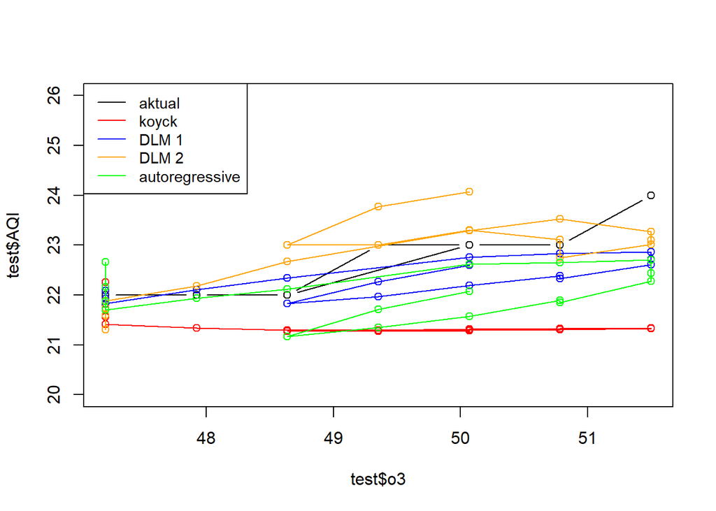

```r
par(mfrow=c(1,1))
plot(test$o3, test$AQI, type="b", col="black", ylim=c(20,26))
points(test$o3, fore.koyck$forecasts,col="red")
lines(test$o3, fore.koyck$forecasts,col="red")
points(test$o3, fore.dlm$forecasts,col="blue")
lines(test$o3, fore.dlm$forecasts,col="blue")
points(test$o3, fore.dlm2$forecasts,col="orange")
lines(test$o3, fore.dlm2$forecasts,col="orange")
points(test$o3, fore.ardl$forecasts,col="green")
lines(test$o3, fore.ardl$forecasts,col="green")
legend("topleft",c("aktual", "koyck","DLM 1","DLM 2", "autoregressive"), lty=1, col=c("black","red","blue","orange","green"), cex=0.9)
```